# Homework 1

Dario Stagnitto

29/4/2018

# Ex 1.A

**Sample survey: Suppose we are going to sample 100 individuals from a county (of size much larger than 100) and ask each sampled person whether they support policy Z or not. Let $Y_i = 1$ if person i in the sample supports the policy, and $Y_i = 0$ otherwise.**

**Assume $Y_1,....,Y_{100}$ are, conditional on $\theta$, i.i.d. binary random variables with expectation $\theta$. Write down the joint distribution of $Pr(Y_1 = y_1, ..., Y_{100} = y_{100} \mid \theta)$ in a compact form. Also write down the form of $P(\sum_{i=1}^{100} Y_i = y \mid \theta)$**

So what we have is:

- $Y_i \mid \theta \sim Ber(\theta)$
- $Y_i \in \{0,1\}$
- $f(y_i\mid\theta) = \theta^y(1-\theta)^{1-y}$

Being i.i.d. our joint distribution will be:

$$P(Y_1 = y_1,....,Y_{100} = y_{100} \mid \theta) = \prod_{i=1}^{100}f(y_i\mid\theta) = \theta^{\sum_{i=1}^{100}{y_i}}(1-\theta)^{100-{\sum_{i=1}^{100}{y_i}}}$$

Since $P(\sum_{i=1}^{100} Y_i = y \mid \theta)$ is sum of 100 $Ber(\theta)$ conditionally iid, using the Bernoulli’s properties it can be written as a $Bin(100,\theta)$. So we have:

$$P(\sum_{i=1}^{100} Y_i = y \mid \theta) = \binom{100}{y}\theta^{y}(1-\theta)^{100-{y}}$$

# Ex 1.B

**For the moment, suppose you believed that $\theta \in \{0.0, 0.1, ..., 0.9, 1.0\}$. Given that the results of the survey were $\sum_{i=1}^{n}Y_i = 57$, compute:**
$$Pr(\sum_{i=1}^{n}Y_i = 57 \mid \theta)$$
**for each of these 11 values of $\theta$ and plot these probabilities as a function of $\theta$.**

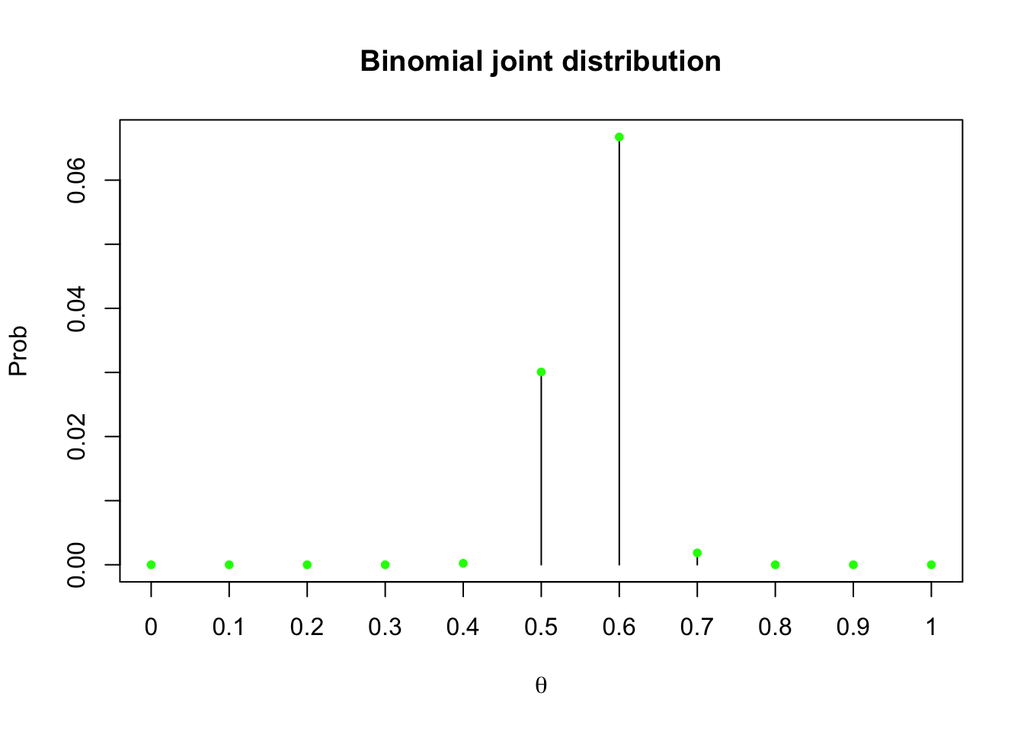

```r
seque <- seq(0,1, by = 0.1)

a = NULL
for (i in 1:length(seque)){

  a[i] <- dbinom(x = 57, size = 100, prob = seque[i])
}

plot(a, type = "h", xaxt = "n", ylab = "Prob", xlab = expression(theta), main = "Binomial joint distribution")
axis(1, at = (1:11), labels = seque)
points(a, pch = 20, col = "green")
```

# Ex 1.C

**Now suppose you originally had no prior information to believe one of these $\theta-values$ over another,and so $Pr(\theta = 0.0) = Pr(\theta = 0.1) = ... = Pr(\theta = 0.9) = Pr(\theta = 1.0)$. Use Bayes rule to compute $\pi(\theta \mid \sum_{i=1}^{n} Y_i = 57)$ for each θ-value.** **Make a plot of this posterior distribution as a function of θ.**

$$\pi(\theta \mid \sum_{i=1}^{n} Y_i = 57) = \frac{P(\sum_{i = 1}^{n} Y_i = 57 \mid \theta) \cdot \pi(\theta)}{\sum_{j = 1}^{n} P(\sum_{i = 1}^{n} Y_i = 57 \mid \theta_j) \cdot \pi(\theta_j)}$$

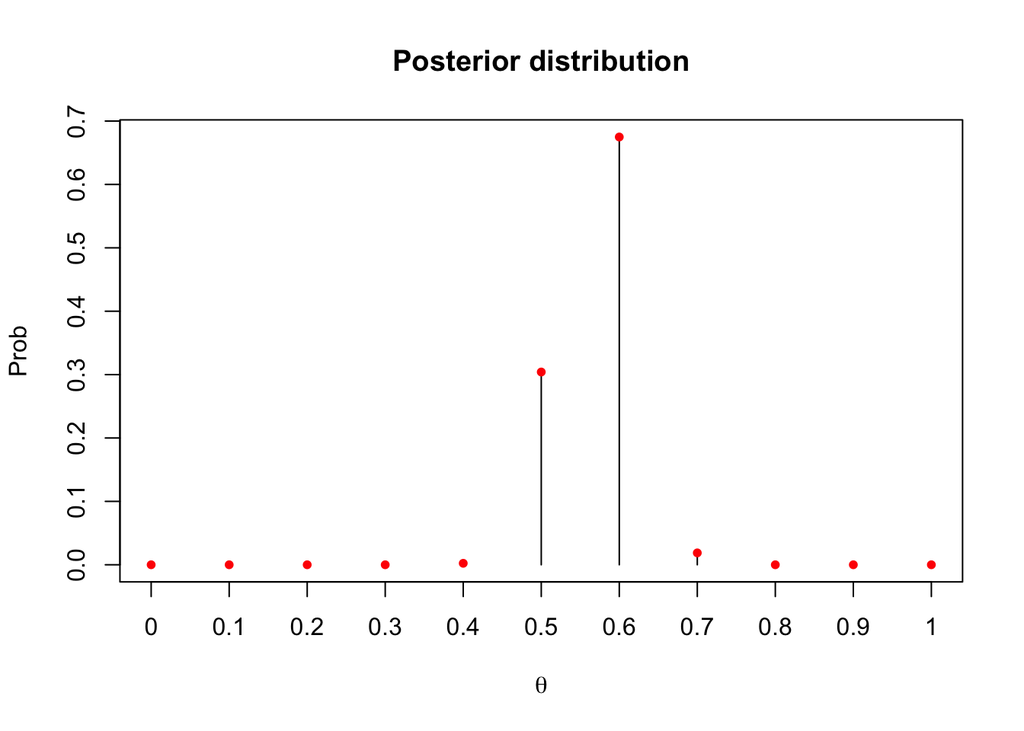

```r
numer <- a*1/11
deno <- sum(a*1/11)

posterior <- numer/deno

plot(posterior, type = "h", xaxt = "n", ylab = "Prob", xlab = expression(theta), main = "Posterior distribution")
axis(1, at = (1:11), labels = seque)
points(posterior, pch = 20, col = "red")
```

# Ex 1.D

**Now suppose you allow $\theta$ to be any value in the interval $\theta = [0, 1]$.** **Using the uniform prior density for $\theta \in [0, 1]$, so that $\pi(\theta) = I[0,1](\theta)$, plot $\pi(\theta) \cdot Pr(\sum_{i=1}^{n} Yi = 57 \mid \theta)$ as a function of $\theta$.**

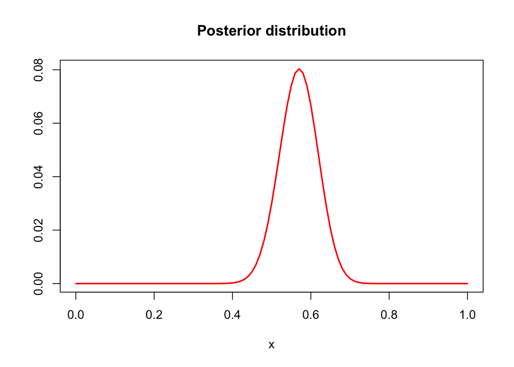

```r
prior <- function(theta){ dunif(theta,0,1) }
posterior <- function(theta){prior(theta)*dbinom(x = 57, size = 100, prob = theta)}
curve(posterior(x), col = "red", lwd = 2, main = "Posterior distribution", xlab = "x", ylab = "")
```

# Ex 1.E

**Plot the posterior density as a function of $\theta$.**

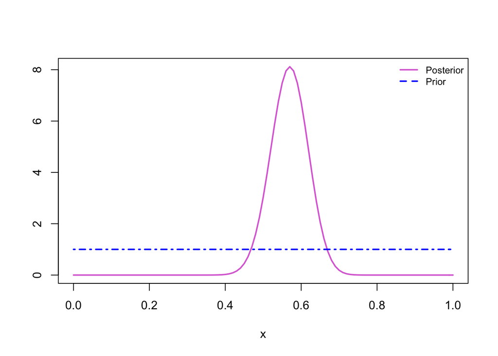

```r
curve(dbeta(x,58,44), col = "orchid", lwd = 2, ylab = "")
curve(dbeta(x,1,1),col = "blue", add = T, lwd = 2, lty = 4)
legend("topright", legend = c("Posterior","Prior"), col = c("orchid","blue"),lty = 1:4,cex = 0.8, lwd = 2, bty = "n" )
```

# Ex 2.A

**Derive the general formula of the prior predictive distribution for a single observation X**.

$$X_i\mid \theta \sim N(\theta,\sigma^2_x)$$

$$\theta \sim N(\theta_0,\sigma^2_\theta)$$

$$P(X') = \int\limits_{-\infty}^\infty P(X',\theta)\mathrm{d}\theta = \int\limits_{-\infty}^\infty P(X' \mid \theta)\cdot P(\theta)\mathrm{d}\theta$$

where $P(X' \mid \theta)$ is the Likelihood and $P(\theta)$ is the prior distribution.

So we have that:

$$X' = (X'-\theta)+\theta$$

Knowing $\theta$:

$$(X' -\theta) \sim N(0,\sigma^2_x)$$

$$X' \sim N(0,\sigma^2_x) + N(\theta_0,\sigma^2_\theta) = N(\theta_0,\sigma^2_x + \sigma^2_\theta)$$

# Ex 2.B

**Derive the general formula of the posterior predictive distribution for a single observation X.**

$$Pr(X'\mid X) = \int_{-\infty}^{+\infty} Pr(X'\mid \theta,X) \cdot \pi(\theta \mid X) d\theta=Pr(X'\mid \theta) \cdot \pi(\theta \mid X) \sim N(\cdot) \cdot N(\theta ',\sigma_{\theta}'^2)$$

$$X'=(X'-\theta)+\theta$$
$$(X'-\theta) \sim N(0,\sigma_x^2)$$
$$\theta \sim N(\theta',\sigma_{\theta}'^2)$$
$$X' \sim N(0,\sigma_x^2) + N(\theta',\sigma_{\theta}'^2)= N(\theta',\sigma_{x}^2 + \sigma_{\theta}'^2)$$

# Ex 2.C

**Elicit your prior distribution on the unknown θ in such a way that your prior mean is 0 and you believe that the unknown $\theta$ is in the interval [−5, 5] with prior probability 0.96**.

```r
griglia <- seq(2,3, by = 0.001)

quant.fun <- function(sd){qnorm((1-0.96)/2,0,sd)+5}

p <- quant.fun(griglia)
which.min(abs(quant.fun(griglia)-0)) #cerchiamo quelli più vicini a 0
```

```
## [1] 436
```

```r
p[436]
```

```
## [1] -0.0008785974
```

```r
# 436*0.001 + 2 = 2.436

qnorm((1-0.96)/2,0,2.4)
```

```
## [1] -4.928997
```

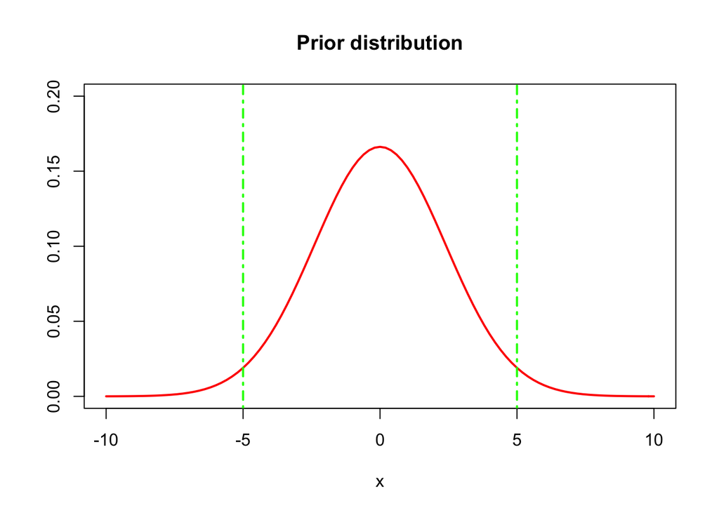

```r
curve(dnorm(x,0,2.4), xlim = c(-10,10), col = "red", ylim = c(0,.2), ylab = "",
      main = "Prior distribution", lwd = 2) #prior distribution
abline(v = c(-5,5), col = "green", lwd = 2, lty = 4)
```

# Ex 2.D

**Assume that the known value of λ is 1/3 and suppose you have observed the following data, derive your posterior distribution and represent it graphically.**

$$−1.25,8.77,1.18,10.66,11.81,−6.09,3.56,10.85,4.03,2.13$$

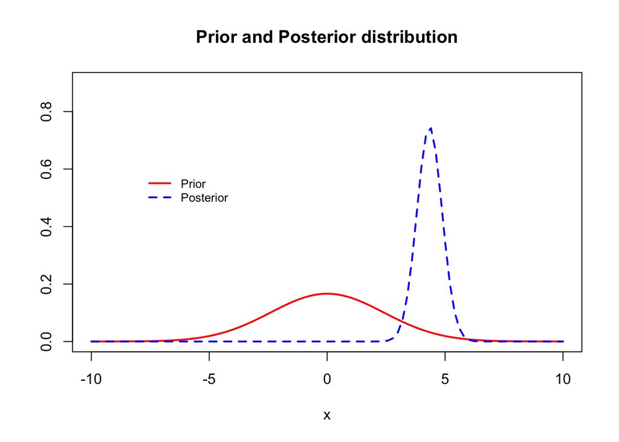

```r
vec <- c(-1.25,8.77,1.18,10.66,11.81,-6.09,3.56,10.85,4.03,2.13)

sigma_2 <- 3
y_bar <- mean(vec)

n <- length(vec)

tau_0 <- 2.4**2
mu_0 <- 0


mu_n <- (1/tau_0*mu_0)/((1/tau_0)+n*(1/sigma_2)) + ((n*(1/sigma_2)*y_bar)/((1/tau_0)+(n*(1/sigma_2))))
tau_n <- 1/((1/tau_0)+n/(sigma_2))

post <- function(theta){ dnorm(theta, mean = mu_n, sd = sqrt(tau_n))}


curve(dnorm(x,0,2.4), xlim = c(-10,10), col = "red", ylim = c(0,0.9),main = "Prior and Posterior distribution", ylab = "", lwd = 2)
curve(post(x), add = T, lwd = 2, col = "blue", lty = 2:4) #posterior
legend(x = -8,y = 0.6, legend = c("Prior","Posterior"), col = c("red","blue"),lty = 1:4,cex = 0.8, lwd = 2, bty = "n")
```

# Ex 2.E

**Derive your favorite point estimate and interval estimate and motivate your choices.**

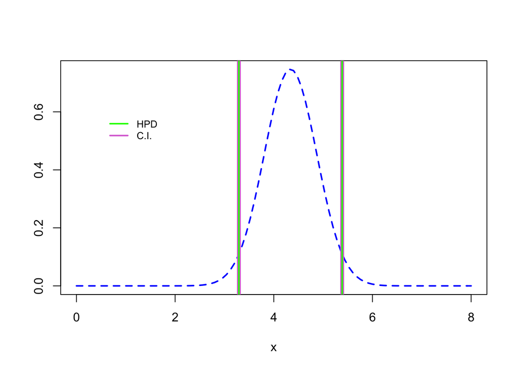

```r
library(TeachingDemos)
C.I <- qnorm(c(0.025,0.975), mean = mu_n, sd = sqrt(tau_n))
hpd <- hpd(qnorm, mean = mu_n,sd = sqrt(tau_n), conf = 0.95)

curve(post(x), lwd = 2, col = "blue", lty = 2:4, xlim = c(0,8), ylab = "")
legend(x = 0.5,y = 0.6, legend = c("HPD","C.I."), col = c("green","orchid"), cex = 0.8, lwd = 2, bty = "n")

abline(v = C.I, col = "orchid", lwd = 5)
abline(v = hpd, col = "green", lwd = 2)
```

```r
diff(hpd)
```

```
## [1] 2.093214
```

```r
C.I[2] - C.I[1]
```

```
## [1] 2.093214
```

As point estimate, the best choice is taking the mean of the posterior distribution that is equal to **4.34**.

In this case, the way how we choose the confidence interval is not so relevant because for the Gaussian distribution, being symmetric, both coincide.

# Ex 3.A

**Consider the following statistical model where $X_i \mid \theta$ are i.i.d with**

$$X_i \mid \theta \sim f(x \mid \theta) = \frac{1}{20}I_{[\theta - 10,\theta+10](x)}$$

**Provide a fully Bayesian analysis for these data explaining all the basic ingredients and steps for carrying it out. In particular, compare your final inference on the unknown $\theta = E[X\mid \theta]$ with the one you have derived in the previous point 2).**

$$X_i \mid \theta \sim Unif(\theta -10, \theta + 10)$$

$$\pi(\theta) \sim N(0,2.4^2)$$

$$L(\theta) = \prod_{i = 1}^{N} \frac{1}{20}I_{[\theta - 10, \theta + 10](x_i)} = \frac{1}{20^n}I_{[x_n - 10,x_1 + 10]}(\theta)$$

Finally, our posterior will be:

$$\pi(\theta \mid X) = \pi(\theta)L(\theta)$$

```r
library(truncnorm)
```

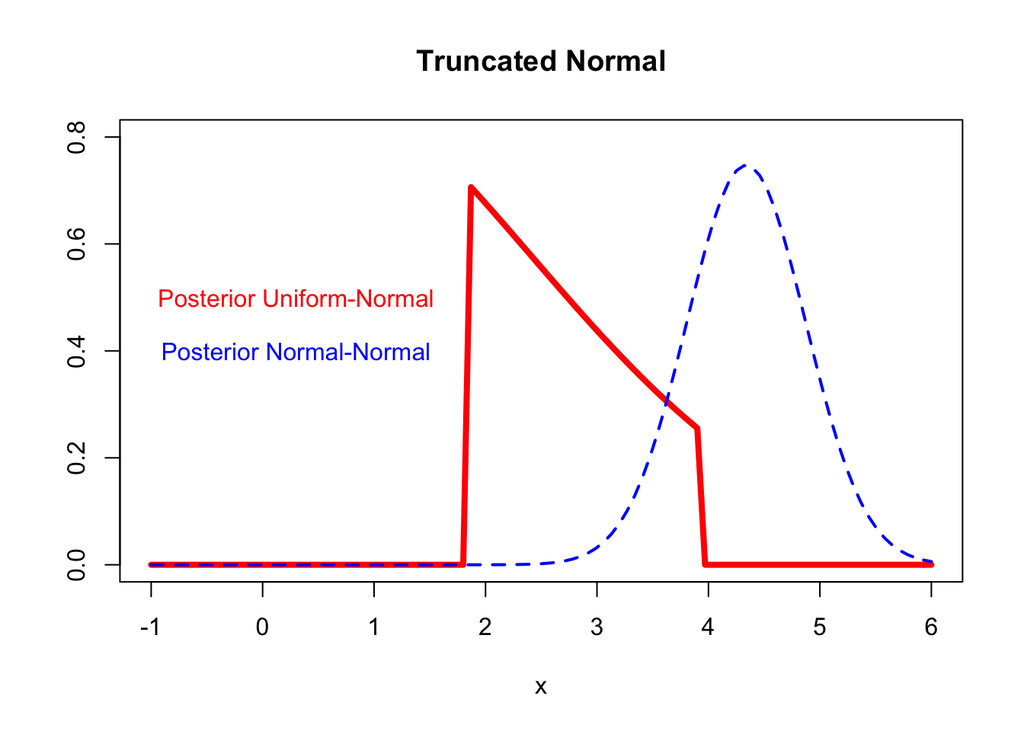

```r
likeli <- function(theta){ (1/(20^n)) * (theta<(min(vec)+10))*(theta>(max(vec)-10))}

post.3 <- function(theta){dtruncnorm(theta,mean = 0,sd = 2.4, a = 1.81, b = 3.91)}

curve(post.3(x), xlim = c(-1,6),ylim = c(0,0.8), ylab = "", col = "red", lwd = 4, main = "Truncated Normal")
curve(post(x), add = T, lwd = 2, col = "blue", lty = 2:4)
text(0.3, 0.5, col = 'red', 'Posterior Uniform-Normal', lwd = 1.5)
text(0.3, 0.4, col = 'blue', 'Posterior Normal-Normal', lwd = 1.5)
```

Our posterior distribution turned out to be a **truncated Normal**.

# Ex 3.B

**Write the formula of the prior predictive distribution of a single observation and explain how you can simulate i.i.d random draws from it. Use the simulated values to represent approximately the predictive density in a plot and compare it with the prior predictive density of a single observation of the previous model.**

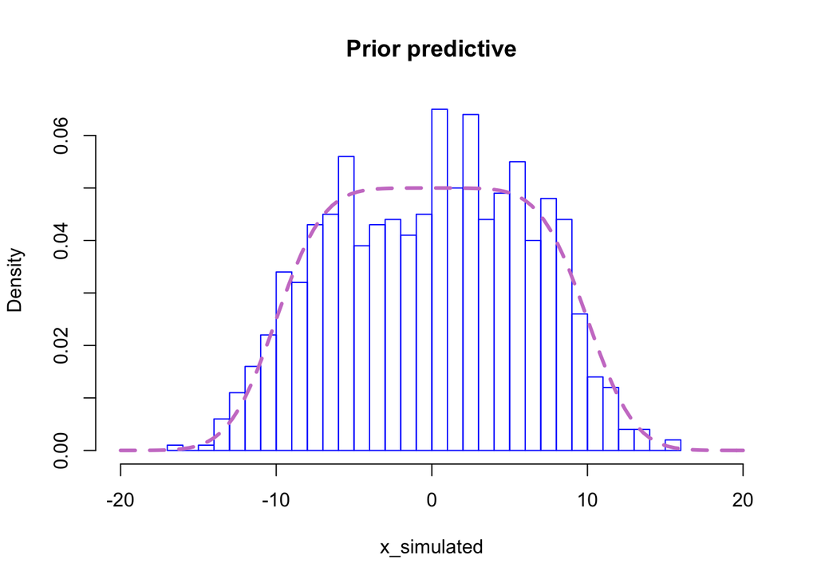

```r
sim <- 1000
sim_theta <- rnorm(sim,mu_0,sqrt(tau_0))
x_simulated <- runif(sim,sim_theta-10,sim_theta+10)


prior.pred <- function(x){ (pnorm(x+10,mu_0,sqrt(tau_0)) - pnorm(x-10,mu_0,sqrt(tau_0)))/20}

hist(x_simulated,freq = F,xlim = c(-20,20),breaks = 40,border = 4,main = 'Prior predictive')
curve(prior.pred,add=T,col=rgb(0.8,0.5,0.8),lwd=3,lty=2)
```

# Ex 3.C

**Consider the same discrete (finite) grid of values as parameter space $\theta$ for the conditional mean $\Theta$ in both models. Use this simplified parametric setting to decide whether one should use the Normal model rather than the Uniform model in light of the observed data.**

To decide whether it’s better use the Normal model rather than the Uniform model, we can compare the two models implemented above in the following way:

$$BF = \frac{Pr(X \mid M_1)}{Pr(X \mid M_2)} = \frac{\int_{\Theta}\pi(\theta)f_1(X \mid \theta)d\theta}{\int_{\Theta}\pi(\theta)f_2(X \mid \theta)d\theta}$$

where **BF** is the **Bayesian Factor**.

```r
# Function for the uniform-normal model
mod_2 <- function(theta)
{
  aux <- 0
  for (theta in sim_theta)
  {
    aux <- aux + prod((vec>=theta-10)*(vec<=theta+10)/20) * dnorm(theta,0,sqrt(tau_0))
  }
  return((aux))
}



# Function for the normal-normal model
mod_1 <- function(theta)
{
  aux <- 0
  for (theta in sim_theta)
  {
  aux <- aux + dnorm(theta,0,sqrt(tau_0)) * prod(dnorm(vec,theta,sqrt(3)))
  }
  return((aux))
}

# Evaluate the Bayes Factor
BF <- mod_1(sim_theta)/mod_2(sim_theta)
BF
```

```
## [1] 6.494642e-18
```

In according to the following table,

| Values | BF Interpretation |
| --- | --- |
| < 1 | Supports model 2 |
| 1-3 | Weak support for model 1 |
| 3-20 | Support for model 1 |
| 20-150 | Strong support for model 1 |
| Over 150 | Very strong support for model 1 |

the model 2 turns out better than the model 1.

# Ex 4.A

The **A-R algorithm** is a basic technique used to generate observations from a distribution. Also called **Rejection sampling**, this algorithm is based on the observation that to sample a random variable one can perform a uniformly random sampling and keep the samples in the region under the graph of its density function.

The steps are the following:

- Generate a random variable Y distributed as G
- Generate U (independent from Y)
- If

$$U \leq \frac{f(Y)}{g(Y)}$$

then X = Y so we **accept** otherwise **reject** and the algorithm starts again. Taking into account our task, we have that our *f(X)* is a Normal distribution and $g(\cdot)$ our Cauchy distribution.

# Ex 4.B

**Provide your R code for the implementation of the A-R**

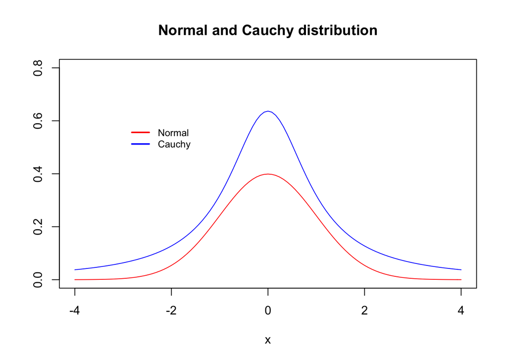

```r
k <- 2
curve(dcauchy(x)*k, xlim = c(-4,4),col = "blue", ylim = c(0,.8), ylab = "", main = "Normal and Cauchy distribution")
curve(dnorm(x), col = "red", add = T)
legend(x = -3, y = 0.6, legend = c("Normal","Cauchy"), col = c("red","blue"),cex = 0.8, lwd = 2, bty = "n")
```

```r
q <- function(x){
  dcauchy(x)
}

draw_from_q=function(n){
  rcauchy(n)
}

f <- function(x){
  dnorm(x)
}


AR <- function(dtarget,dauxiliary,rauxiliary,k){

  count=0
  E=0

  while(E==0){
    candidate = rauxiliary(1)
    acc_prob=dtarget(candidate)/(k*dauxiliary(candidate))
    E = sample(c(1,0),prob=c(acc_prob, 1-acc_prob),size=1)
    count=count+1
  }

  return(list(draw=candidate,computational_effort=count))

}


AR(dtarget=q,dauxiliary=q,rauxiliary=draw_from_q,k)
```

```
## $draw
## [1] 2.374009
##
## $computational_effort
## [1] 1
```

```r
mcsize=1000
draw_vec=rep(NA,mcsize)
effort_vec=rep(NA,mcsize)

for(i in 1:mcsize){

  DD=AR(dtarget=f,dauxiliary=q,rauxiliary=draw_from_q,k = k)
  draw_vec[i] = DD$draw
  effort_vec[i] = DD$computational_effort

}
```

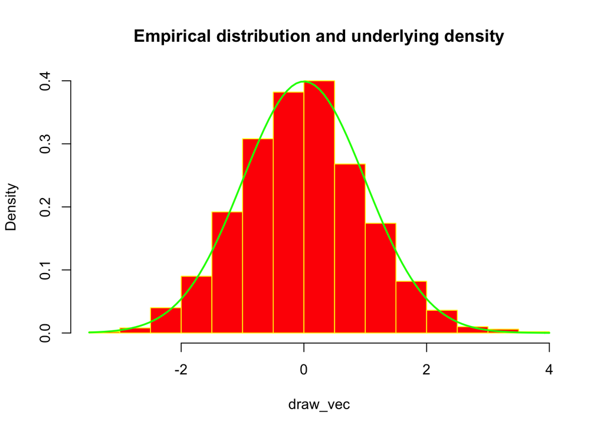

```r
hist(draw_vec,freq=FALSE, col = "red", border = "yellow", main = "Empirical distribution and underlying density")
curve(f(x),add=TRUE, col = "green", lwd = 2)
```

# Ex 4.C

**Evaluate numerically (approximately by MC) the acceptance probability.**

```r
accept.prob <- mcsize/sum(effort_vec)
accept.prob
```

```
## [1] 0.5107252
```

# Ex 4.D

**Write your theretical explanation about how you have conceived your Monte Carlo estimate of the acceptance probability.**

In the code I simulated the A-R algorithm for 1000.

Once implemented that, I estimated the acceptance probability simply dividing the number of iterations for the sum of the “effort_vec” whose data inside are the number of the iterations which assumes 1 as value.

# Ex 4.E

**Save the rejected simulations and provide a graphical representation of the empirical distribution (histogram or density estimation).**

```r
AR.2 <- function(dtarget,dauxiliary,rauxiliary,k){

  count=0
  E=0
  reject <- NULL

  while(E==0){
    candidate = rauxiliary(1)
    acc_prob=dtarget(candidate)/(k*dauxiliary(candidate))
    E = sample(c(1,0),prob=c(acc_prob, 1-acc_prob),size=1)
    if (E == 0){

      reject[count] <- candidate
    }

    count=count+1

  }

  return(list(draw=candidate,computational_effort=count,rej = reject))

}


AR.2(dtarget=q,dauxiliary=q,rauxiliary=draw_from_q,k)
```

```
## $draw
## [1] -115.0859
##
## $computational_effort
## [1] 2
##
## $rej
## numeric(0)
```

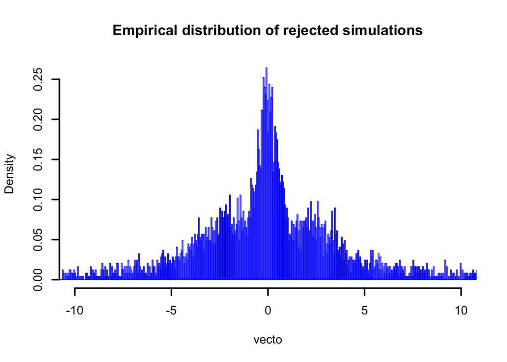

```r
mcsize=10000
draw_vec=rep(NA,mcsize)
effort_vec=rep(NA,mcsize)
vecto <- c()

for(i in 1:mcsize){

  DD=AR.2(dtarget=f,dauxiliary=q,rauxiliary=draw_from_q,k = k)
  draw_vec[i] = DD$draw
  effort_vec[i] = DD$computational_effort
  vecto <- c(vecto,DD$rej)

}


hist(vecto, breaks = 100000,xlim = c(-10,10), freq = F, border = "blue", lwd = 2, main = "Empirical distribution of rejected simulations")
```

# Ex 4.F

**Derive the underlying density corresponding to the rejected random variables and try to compare it with the empirical distribution.**

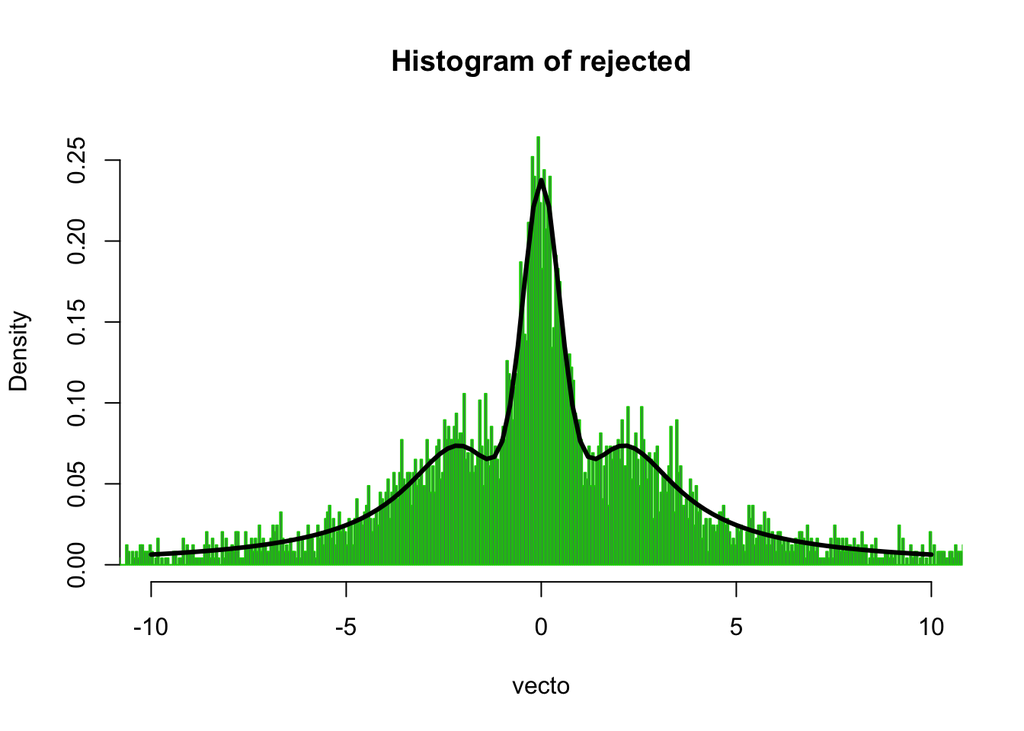

```r
hist(vecto,breaks = 100000,freq = FALSE,border = 3,xlim=c(-10,10),col = rgb(0.5,0.2,0.7),main='Histogram of rejected')
rejected_distr <- function(x) (dcauchy(x)*(1-(dnorm(x))/(k*dcauchy(x))))/(1-1/k)
curve(rejected_distr(x),add=T,lwd=3)
```

# Ex 5.A

**Marginal likelihood evaluation for a Poisson data model. Simulate 10 observations from a known Poisson distribution with expected value 2.**

**Use set.seed(123) before starting your simulation.**

**Use a Gamma(1,1) prior distribution and compute the corresponding marginal likelihood in 3 different ways:**

- exact analytic computation

```r
set.seed(123)

n <- 10
M <- 1
if ( M == 1){
  x_obs = rpois(n,2)
}

fun <- function(theta){prod(1/factorial(x_obs))*theta^(24)*exp(1)^(-11*theta)}
integrale <- integrate(fun, lower = 0, upper = Inf)
value <- integrale$value
value
```

```
## [1] 4.314297e-09
```

# Ex 5.B

- by Monte Carlo approximation using a sample form the posterior distribution and the harmonic mean approach. Try to evaluate random behaviour by repeating/iterating the approximation $\hat{I}$ a sufficiently large number of times and show that the approximation tends to be (positively) biased. Use these simulations to evaluate approximately the corresponding variance and mean square error.

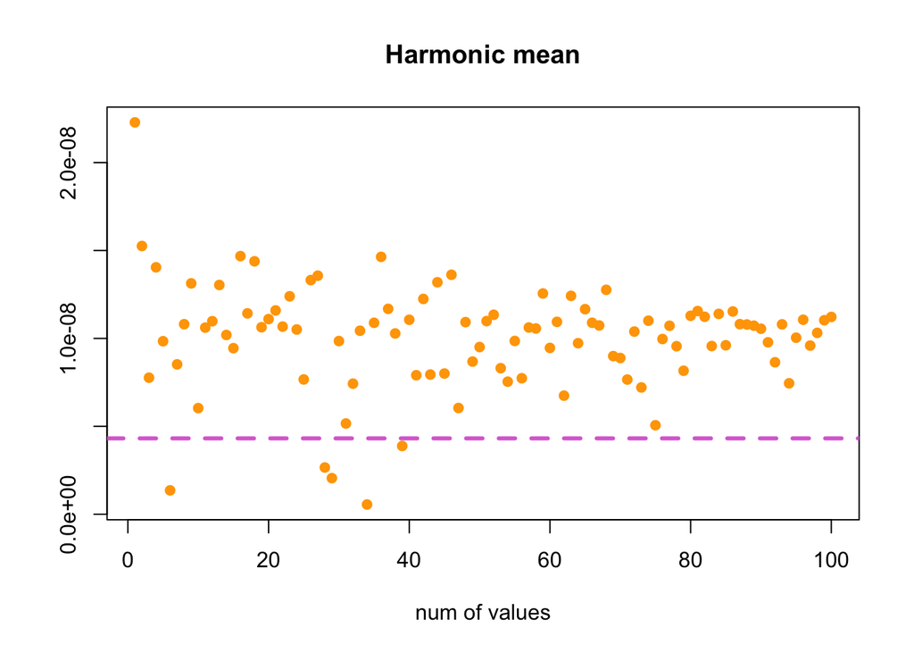

```r
set.seed(123)
obs <- rpois(10,2)
prior <- function(theta){ dgamma(theta,1,1)}

seq <- seq(100,10000, by = 100)

likel.pois <- Vectorize(function(theta){((theta^sum(obs))*exp(-length(obs)*theta))/prod(factorial(obs))})

eps.HM <- function(t){
  sample <- rgamma(t, shape = sum(obs) + 1, rate = 1 + length(obs))
  out <- 1/mean(1/likel.pois(sample))
  return(out)
  }


vec = c()
for (i in seq){
  vec <- c(vec,eps.HM(i))
}

plot(vec, main = "Harmonic mean", xlab = "num of values", ylab = "", col = "orange", pch = 20, lwd = 3)
abline(h = 4.314297e-09, lty = 2, col = "orchid", lwd = 3)
```

# Ex 5.C

- by Monte Carlo Importance sampling choosing an appropriate Cauchy distribution as auxiliary distribution for the simulation. Compare its performance with respect to the previous harmonic mean approach.

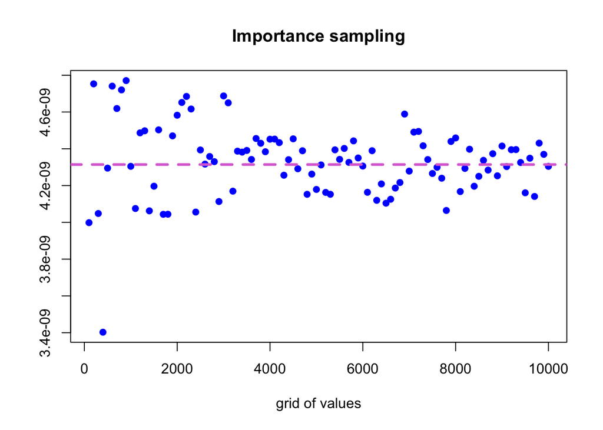

```r
import.sampl <- Vectorize(function(t){

  val <- abs(rcauchy(t,0,1))
  out <- mean(likel.pois(val)*dgamma(val,1,1)/(2*dcauchy(val,0,1)))

  return(out)
  })


r <- import.sampl(seq)

plot(x = seq,y = r, main = "Importance sampling", xlab = "grid of values", ylab = "", col = "blue", pch = 20, lwd = 3)
abline(h = 4.314297e-09, lty = 2, col = "orchid", lwd = 3)
```

# Ex 6.A

**Provide two alternative implemetations of 10000 i.i.d. simulations from the following left-truncated normal distribution**

$$f(x) \propto exp\{{-\frac{1}{2}\frac{(x+1)^2}{10}}\}I_{(-2,\infty)}(x)$$

**using:**

- integral transform i.e. using the inverse CDF

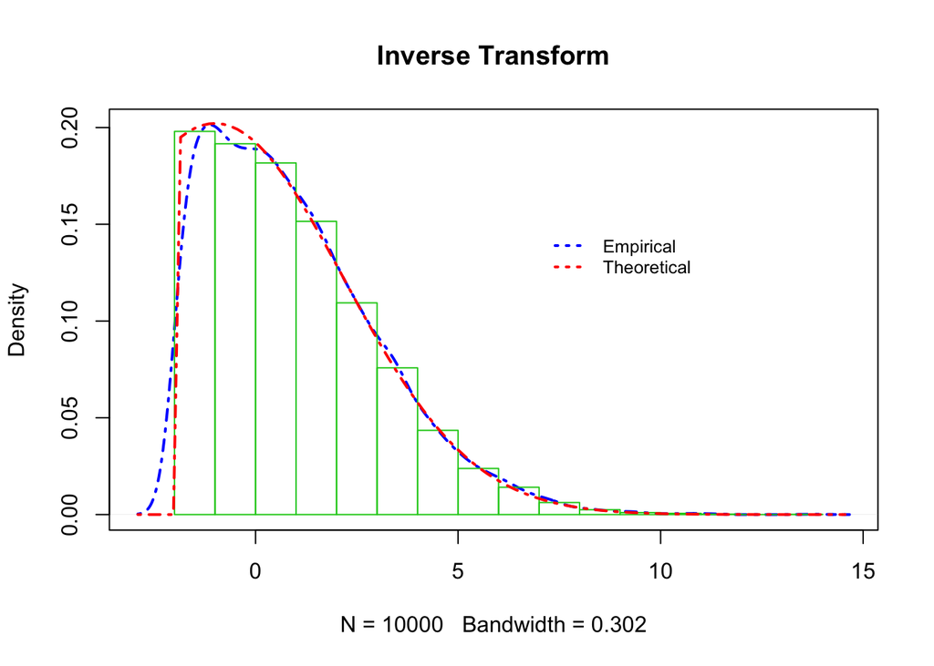

```r
library(truncnorm)
a <- -2
b <- Inf

mu <- -1
sigma2 <- 10
sd <- sqrt(sigma2)

alpha = (a - mu)/sd
beta = (b -mu)/sd

x <- qnorm(pnorm(alpha)+runif(10000)*(pnorm(beta)-pnorm(alpha)))*sd+mu


plot(density(x), col = "blue", lwd = 2, lty = 4, main = "Inverse Transform") #empirical
hist(x,freq = F ,add = T, border = "#1acc1d", cex = 1.3)
curve(dtruncnorm(x, a = a, b = b, mean = -1, sd = sqrt(10)), col = "red",lwd = 2,
      lty = 4,add = T) #theoretical
legend(x = 7,y = 0.15, legend = c("Empirical","Theoretical"), col = c("blue","red"), lty = c("dotted"),cex = 0.8, lwd = 2, bty = "n")
```

# Ex 6.B

- Acceptance-rejection

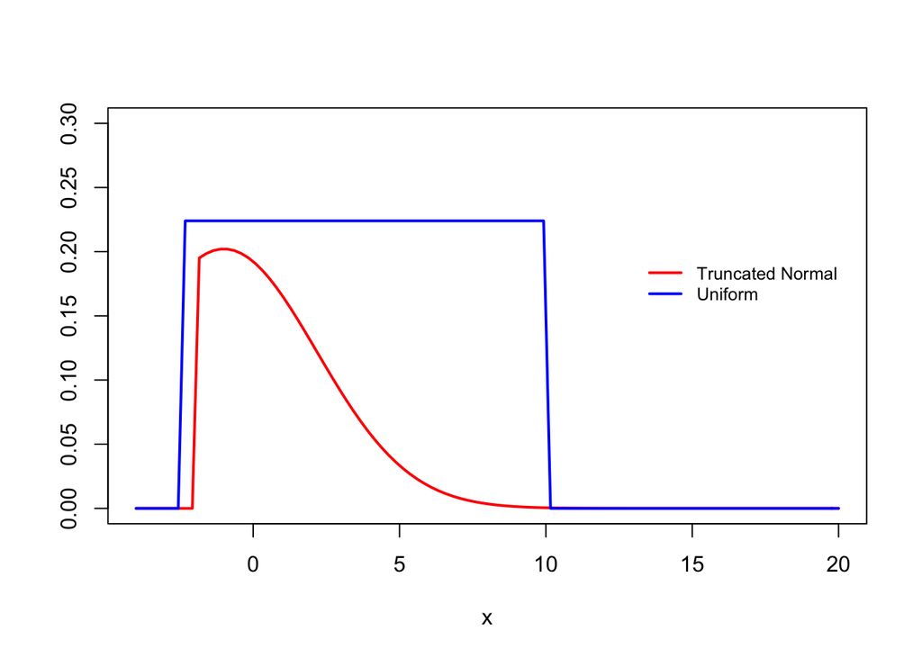

```r
library(truncnorm)

k <- 2.8
curve(dtruncnorm(x, a = a, b = b, mean = -1, sd = sqrt(10)), col = "red", xlim = c(-4,20),ylim = c(0,.3), ylab = "", lwd = 2)
curve(dunif(x,-2.5,10)*k,col = "blue", ylim = c(0,.8),add = T, lwd = 2)
legend(x = 13,y = 0.20, legend = c("Truncated Normal","Uniform"), col = c("red","blue"),cex = 0.8, lwd = 2, bty = "n")
```

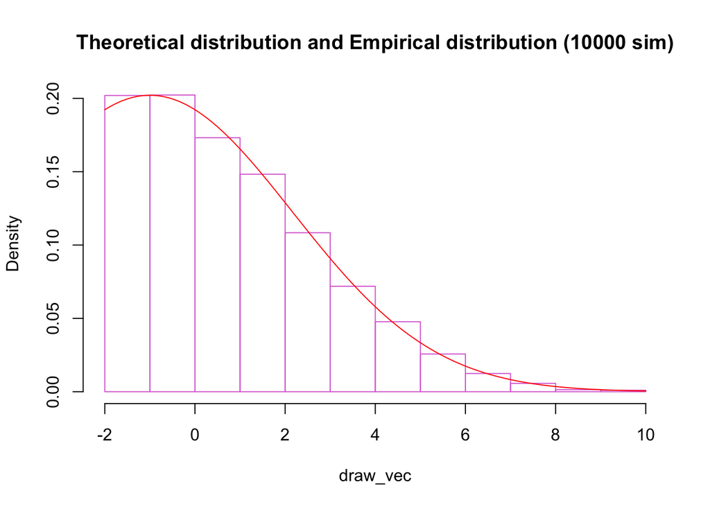

```r
funct <- function(x){
  dunif(x,-2,10)
}

draw_from_q=function(n){
  runif(n,-2,10)
}

f <- function(x){
  dtruncnorm(x, a = a, b = b, mean = -1, sd = sqrt(10))
}



AR <- function(dtarget,dauxiliary,rauxiliary,k){

  count=0
  E=0

  while(E==0){
    candidate = rauxiliary(1)
    acc_prob=dtarget(candidate)/(k*dauxiliary(candidate))
    E = sample(c(1,0),prob=c(acc_prob, 1-acc_prob),size=1)
    count=count+1
  }

  return(list(draw=candidate,computational_effort=count))

}


mcsize=10000
draw_vec=rep(NA,mcsize)
effort_vec=rep(NA,mcsize)

for(i in 1:mcsize){

  DD=AR(dtarget=f,dauxiliary=funct,rauxiliary=draw_from_q,k=k)
  draw_vec[i] = DD$draw
  effort_vec[i] = DD$computational_effort

}


hist(draw_vec,freq=FALSE, border = "orchid", main = "Theoretical distribution and Empirical distribution (10000 sim)")
curve(f(x),add=TRUE, col = "red")
```